# R Notebook

Setting up packages and clearing R’s brain

```r
rm(list = ls())
library(here)
library(ggplot2)
library(ggfortify)
library(tidyverse)
```

Importing data

```r
soil <- read.csv(here("Data", "soil_reduced-1.csv"))
```

First, I need to determine the relationship between SOM % and Ca (ppm). I’ll create a histogram to check for outliers in SOM

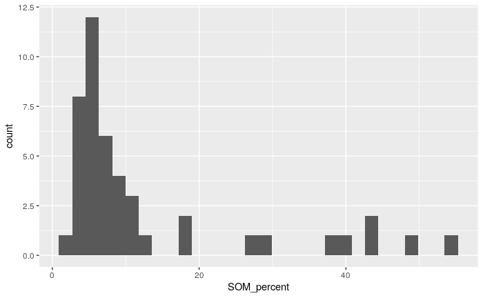

```r
ggplot(soil, aes(x = SOM_percent)) +
  geom_histogram()
```

There don’t appear to be any isolated outliers, so I’ll check Ca in the same way.

```
Warning: Removed 1 rows containing non-finite values (stat_bin).
```

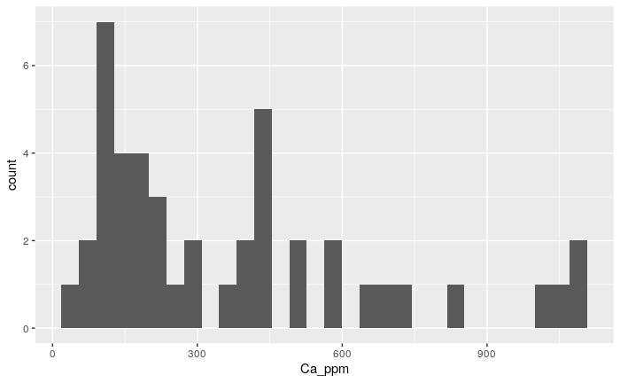

```r
ggplot(soil, aes(x = Ca_ppm)) +
  geom_histogram()
```

This looks good, too. Now, to run a summary of all variables in the data set. This will give us a better idea of how good our data is.

```r
summary(soil)
```

```
           Forest   SOM_percent    Nitrate.N_ppm      Buffer_pH          Ca_ppm
 DEGRASSE     :9   Min.   : 2.66   Min.   :  0.00   Min.   : 3.360   Min.   :  48.0
 DONNERVILLE  :9   1st Qu.: 5.07   1st Qu.:  0.00   1st Qu.: 4.860   1st Qu.: 142.5
 KIP TRACT    :9   Median : 6.82   Median :  4.50   Median : 5.160   Median : 267.5
 PEAVINE      :9   Mean   :12.94   Mean   : 12.66   Mean   : 6.138   Mean   : 374.0
 SOUTH HAMMOND:9   3rd Qu.:10.57   3rd Qu.: 13.25   3rd Qu.: 5.520   3rd Qu.: 497.5
                   Max.   :55.21   Max.   :199.00   Max.   :52.900   Max.   :1101.0
                                   NA's   :13                        NA's   :1
     P_ppm            Mg_ppm           K_ppm            Na_ppm          Zn_ppm
 Min.   :  3.00   Min.   : 11.00   Min.   : 18.00   Min.   :12.00   Min.   : 1.300
 1st Qu.:  8.00   1st Qu.: 28.50   1st Qu.: 40.25   1st Qu.:15.00   1st Qu.: 2.775
 Median : 13.00   Median : 49.00   Median : 53.00   Median :16.00   Median : 4.250
 Mean   : 19.73   Mean   : 59.48   Mean   : 59.98   Mean   :17.02   Mean   : 6.055
 3rd Qu.: 17.00   3rd Qu.: 79.75   3rd Qu.: 72.75   3rd Qu.:19.00   3rd Qu.: 7.850
 Max.   :157.00   Max.   :174.00   Max.   :164.00   Max.   :30.00   Max.   :22.000
 NA's   :1        NA's   :1        NA's   :1        NA's   :1       NA's   :1
     Worms
 Min.   : 0
 1st Qu.: 0
 Median : 1
 Mean   : 2
 3rd Qu.: 2
 Max.   :21
```

There appear to be a lot of ‘NA’ throughout this data. That isn’t good, as it means that certain samples were not adequate. Certain means are far different than max values as well, such as for Zn_ppm among others.

Now, it’s time to determine the relationship between SOM_percent and Ca_ppm. As these are both forms of continuous data, a scatterplot should do the trick.

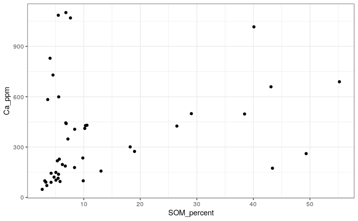

```r
ggplot(soil, aes(x = SOM_percent, y = Ca_ppm)) +
  geom_point() +
  theme_bw()
```

Now, I’ll need top guess the relationship between variables. Judging from this scatterplot, there is a weak positive relationship between SOM_percent ans Ca_ppm. It appears that there’s a general trend, but it isn’t too clearly defined and points aren’t very close.

Since both the response and predictor are continuous, linear regression should be used to further analyze this data.

```r
SOM_CA_mod <- lm(Ca_ppm ~ SOM_percent, data = soil)
```

Checking model assumptions prior to interpretation.

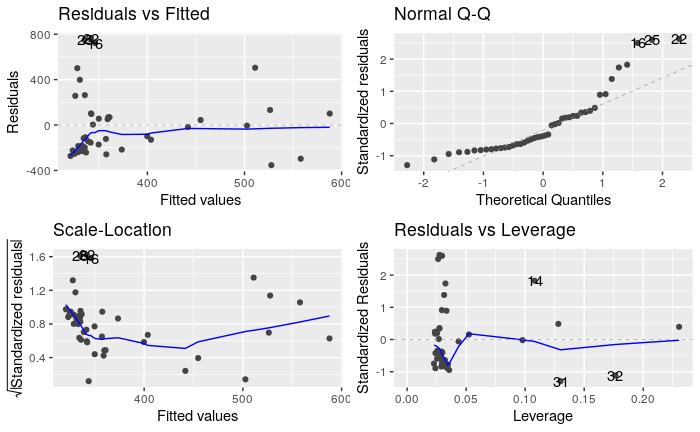

```r
autoplot(SOM_CA_mod)
```

Now, we can look at the model outcome.

```r
anova(SOM_CA_mod)
```

```
Analysis of Variance Table

Response: Ca_ppm
            Df  Sum Sq Mean Sq F value Pr(>F)
SOM_percent  1  219904  219904  2.5611  0.117
Residuals   42 3606294   85864
```

As p is greater than .05, there is no significant correlation between SOM_percent and Ca_ppm. This demonstrates a null hypothesis–no statistical relationship between the chosen variables.

Next, to check if the abundance of worms differs between Donnerville and Kip Tract.

I’ll start by making ‘Forest’ a factor.

```r
soil$Forest <- as.factor(soil$Forest)
```

Now, I’ll select for solely worm data from Donnerville and Kip Tract

```r
Donner_Kip_Worms <- soil[c(1, 11)]

Donner_Kip_Worms <- Donner_Kip_Worms[10:27, ]
```

Histogram to check for outliers. Data appears to be quite even with no noticeable outliers.

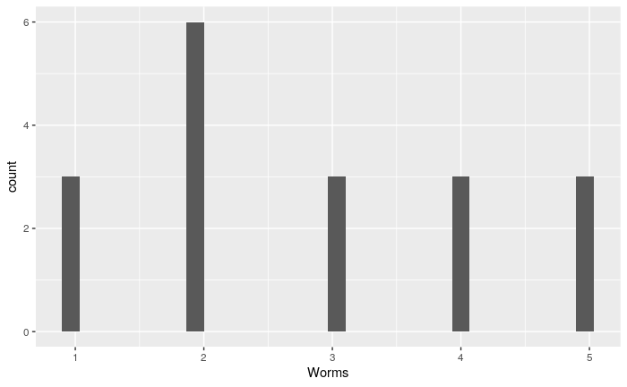

```r
ggplot(Donner_Kip_Worms, aes(x = Worms)) +
  geom_histogram()
```

As there is a difference between the two group means, a two sample t-test should be used.

```r
t.test(Worms ~ Forest, data = Donner_Kip_Worms)
```

```
    Welch Two Sample t-test

data:  Worms by Forest
t = -5.078, df = 13.517, p-value = 0.0001877
alternative hypothesis: true difference in means between group DONNERVILLE and group KIP TRACT is not equal to 0
95 percent confidence interval:
 -3.005781 -1.216441
sample estimates:
mean in group DONNERVILLE   mean in group KIP TRACT
                 1.777778                  3.888889
```

From this test, we can tell that there is a statistically significant difference between worms found at Donnerville and those collected from Kip Tract.

Now, I’ll check on the difference between Mg_ppm in soil from Peavine and South Hammond. This code will look similar to the last problem.

```r
Peav_South_Mg <- soil[c(1, 7)]

Peav_South_Mg <- Peav_South_Mg[28:45,]
```

Histogram to check for outliers. It appears that there may be one at approximately 120 ppm, which could throw off data to some degree.

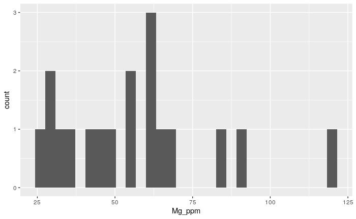

```r
ggplot(Peav_South_Mg, aes(x = Mg_ppm)) +
  geom_histogram()
```

I’ll use a t test again to determine the relationship between these two means (Peavine and South Hammond)

```r
t.test(Mg_ppm ~ Forest, data=Peav_South_Mg)
```

```
    Welch Two Sample t-test

data:  Mg_ppm by Forest
t = -1.2749, df = 14.614, p-value = 0.2222
alternative hypothesis: true difference in means between group PEAVINE and group SOUTH HAMMOND is not equal to 0
95 percent confidence interval:
 -38.648995   9.760106
sample estimates:
      mean in group PEAVINE mean in group SOUTH HAMMOND
                   49.00000                    63.44444
```

As this p value is greater than .05, there is no statistically significant relationship between Mg_ppm at either site.

Finally, to compare Zinc abundance between all forests. Let’s gather data for only zinc and forest type.

```r
Zinc <- soil[c(1, 10)]
```

Checking for outliers. There may be one at approximately 22 ppm, considering how far it is from most other points. I expect there to be a significant difference between forests, considering there is a great deal of variation in the data.

```
Warning: Removed 1 rows containing non-finite values (stat_bin).
```

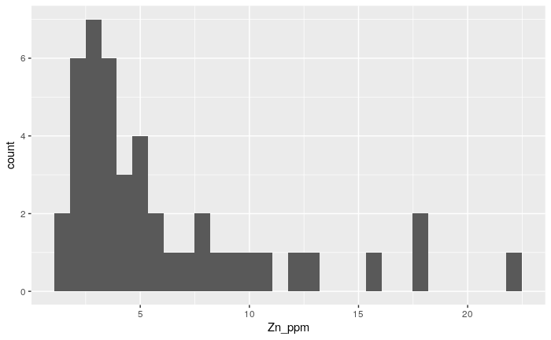

```r
ggplot(Zinc, aes(x = Zn_ppm)) +
  geom_histogram()
```

I’ll use a chi squared test to determine a relationship between categories (all forest types).

```r
Zinc_Mat <- xtabs(Zn_ppm ~ Forest, data = Zinc)

chisq.test(Zinc_Mat)
```

```
    Chi-squared test for given probabilities

data:  Zinc_Mat
X-squared = 24.467, df = 4, p-value = 6.439e-05
```

This test determines that there is a significant difference in zinc content between forest locations.